# Analysis Progress Meeting 3/24

Matt Clark

3/24/2020

# Overall data

Looking at the overall, linear trends of smoke on vis didn’t yeild any immediatly apparent insights

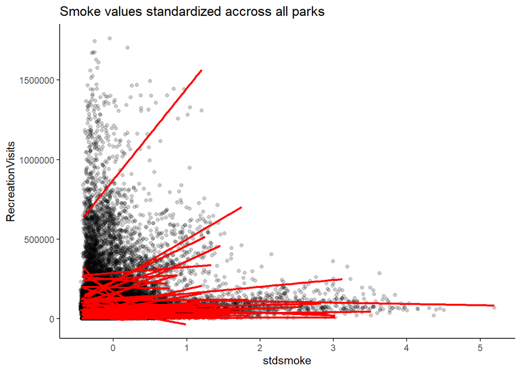

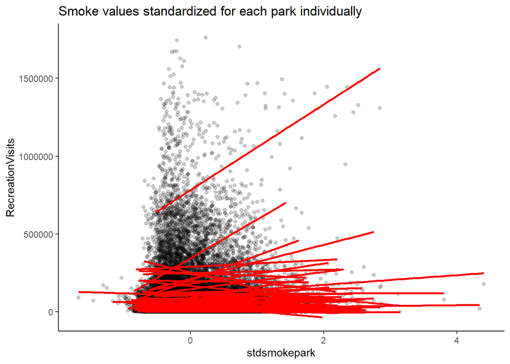

So I also looked at the polynomial curves

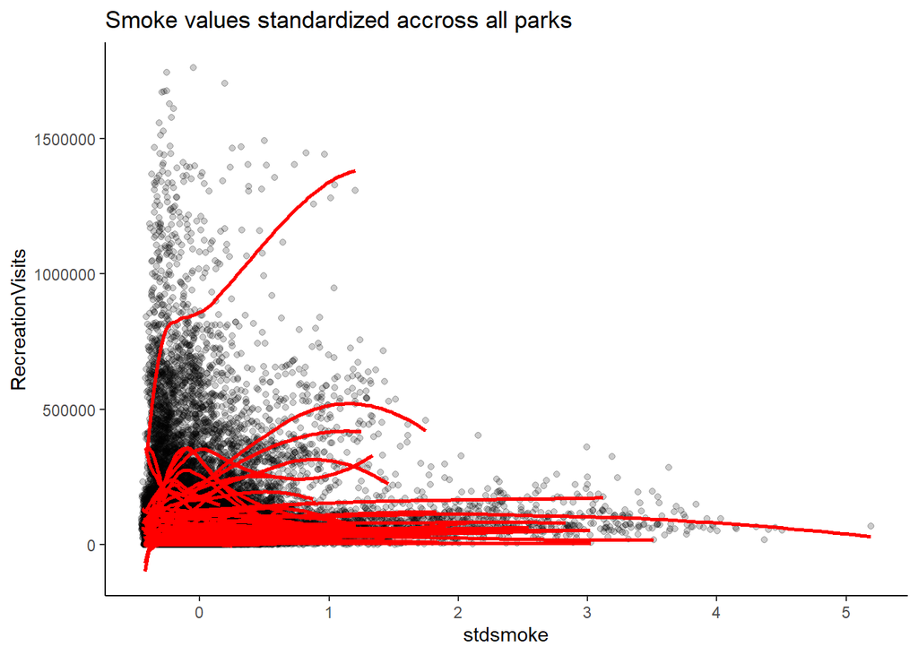

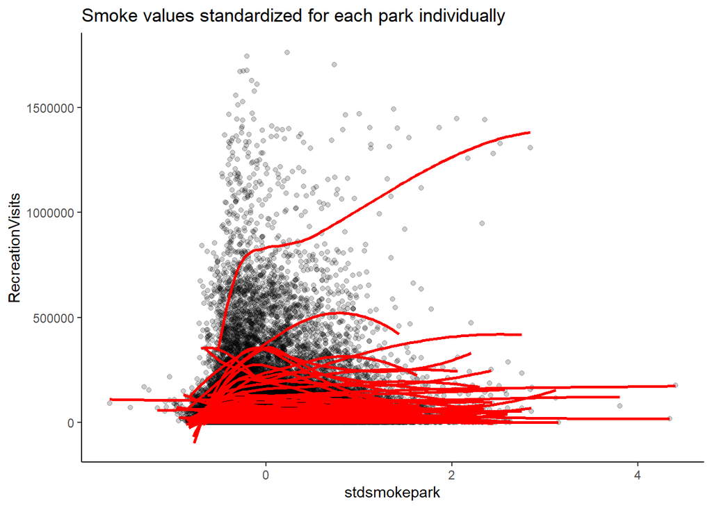

These apprear to have a breakpoint, i.e. vis increases with smoke (due to season) up to a certain point, but then rapidly drops off. We can model this and get breakpoint estimates at least for a subset of parks

I don’t actually think that this is a good idea though. I think these plots have an overwhelming effect of season. Many parks when there is no smoke, it actually makes no sense to go there e.g. Rocky Mountain. The problem is that not all parks have the same visitation or smoke trends by season.

[figure not shown]

It might be better to just compare between high, low, and shoulder seasons for each park.

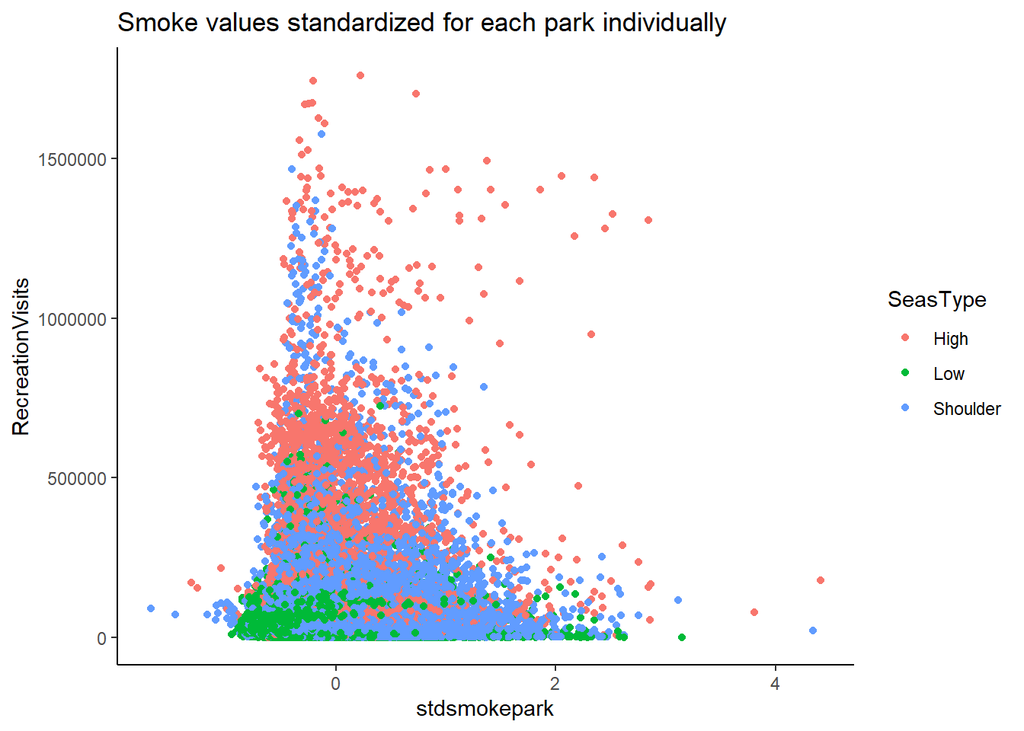

One obvious starting place here is to just look at the high season for each park.

We can look at the by park standardization and the overall standardiztion.

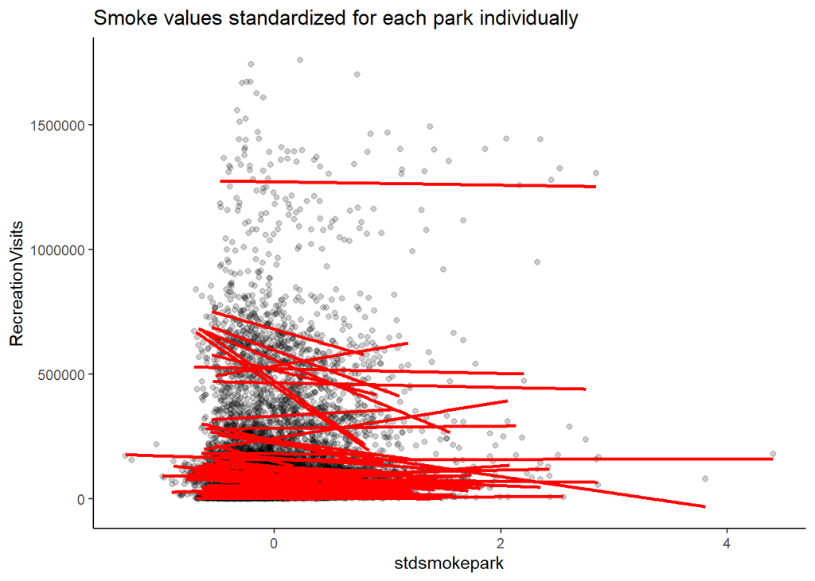

[figure not shown]

Let’s look at some simple model outputs for these

Standardized overall

**Didn’t converge for some reason, I’ll work on it today**

Standardized by park

**Didn’t converge for some reason, I’ll work on it today**

Let’s look at this for the other seasons now

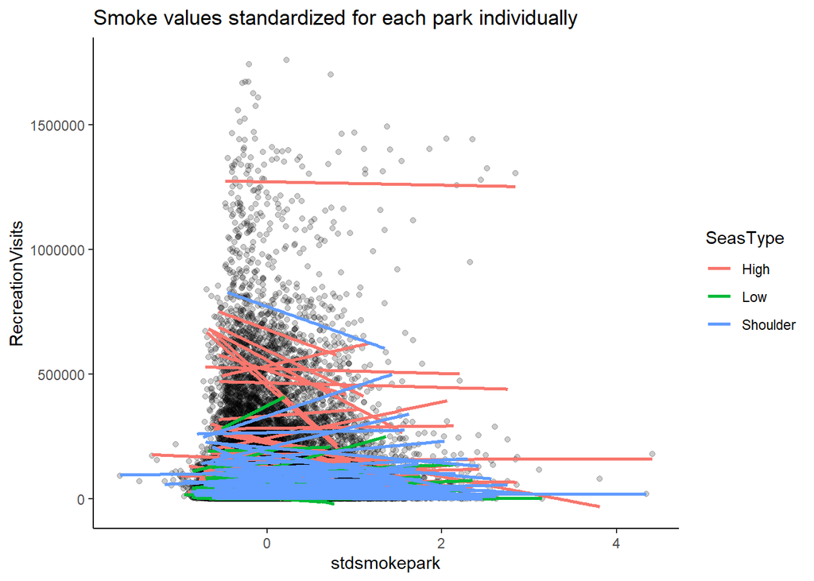

```r
ggplot(dat,aes(x=stdsmokepark,y=RecreationVisits,by=UnitCode))+
  geom_point(alpha=0.2)+
  geom_smooth(aes(color=SeasType),se=F,alpha=0.6,method="lm")+
  theme_classic()+ggtitle("Smoke values standardized for each park individually")
```

Might be interesting to look at the polynomials for those too

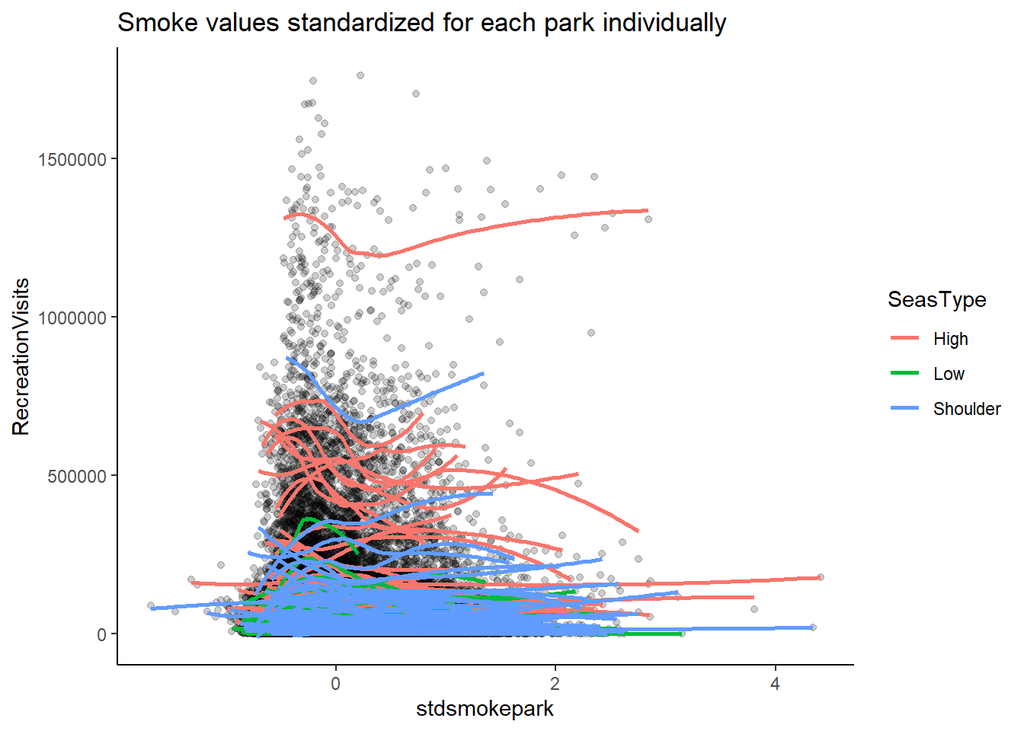

```r
ggplot(dat,aes(x=stdsmokepark,y=RecreationVisits,by=UnitCode))+
  geom_point(alpha=0.2)+
  geom_smooth(aes(color=SeasType),se=F,alpha=0.6)+
  theme_classic()+ggtitle("Smoke values standardized for each park individually")
```

I’m not really sure what to make of that weird upswing that we see. I ran a breakpoint model on just the high season for these data and it picked up the upswing at the primary breakpoint. Basically the opposite of our hypothesis. I think that there’s just a few high leverage points causing this though, I think this because of how wide the std error gets over there.

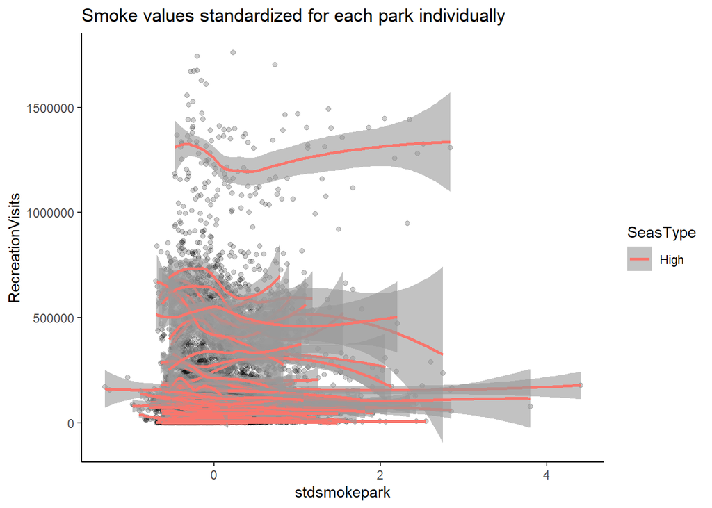

# Overall insights